# Chapter 07 ; 인공지능에 쓰이는 논리와 추론

규칙기반 인공지능의 추론 및 전문가 시스템과 인공지능 문제들을 탐구한다.

7.1 인공지능에 쓰이는 논리와 추론  
7.2 인공지능에서의 탐색 기법  
7.3 인공지능과 알고리즘  
7.4 규칙기반 전문가 시스템  
7.5 인공지능과 관련된 흥미로운 문제들

## 7.1 인공지능에 쓰이는 논리와 추론

### (1) 규칙기반 인공지능에서의 논리와 추론

- 인공지능 중 규칙기반 인공지능에서는 논리를 바탕으로 규칙을 통해 추론하는 것이 상당히 중요한 논제
- 논리는 다양한 논리 연산을 통해 규칙기반 인공지능에서 폭넓게 활용되고 있다.
- 여러가지 탐색방법, 문제해결을 위한 알고리즘, 지식처리 등을 학습
- 전문가 시스템의 응용에 있어서 필수적인 기반 지식
- 논리의 의미와 다양한 논리 연산들을 살펴볼 필요가 있다.

[figure not shown]

### (2) 논리란 무엇인가?

- 논리의 사전적 의미는 말이나 글에서 사고나 추리 따위를 이치에 맞게 이끌어 가는 과정이나 원리
- 토론이나 논쟁에 있어서 가장 중요한 것
- 자기의 뜻을 굽히지 않고 열정적으로 주장하는것도 의미는 있음
- 상대방을 논리적으로 설득하는 것이 가장 중요
- 인간의 사고가 논리적인지 판단하는 것은 주어진 문제를 객관적이고 명확하게 사고를 체계적으로 준수하느냐에 따라 결정
- 논리의 중요한 목적 중 하나는 어떤 토론에서 특정 논리를 통한 입증이 옳은가를 측정하는데 필요한 법칙을 제공한다는 것

[figure not shown]

#### 논리의 활용

- 컴퓨터 관련 학문이나 공학 등의 분야에 폭넓게 응용됨
- 위의 분야 외에도 다양한 분야에서 응용됨
- 특히, 논리와 명제는 규칙기반(rule-based) 인공지능에 필수적인 이론적 기반을 제공
- 많은 학자들이 이와 같은 중요 논리를 규칙기반 인공지능을 통해 실험하는 방법을 연구
- 논리는 인공지능에서 지식의 표현, 추론의 도구로 많이 쓰이고 있음

[figure not shown]

#### 닭이 먼저인가 달걀이 먼저인가?

```python
from IPython.display import YouTubeVideo
YouTubeVideo('1a8pI65emDE')
# https://youtu.be/1a8pI65emDE
```

[video not shown]

### (3) 논리 연산

- 명제 논리(propositional logic) 술어 논리(predicate logic) 두가지로 크게 구분할 수 있음
- 명제 논리는 전체의 참/거짓을 판별하는 법칙 다룸
- 술어 논리는 주어와 술어로 구분하여 참/거짓 법칙 다룸
- 명제(proposition)는 논리에서 가장 기초적인 개념
- 어떤 사고를 나타내는 문장 중 애매하지 않고 명확하게 참이나 거짓으로 구분할 수 있는 문장이나 수학적 식을 말함
- 예를 들어 "2 x 7의 값은 홀수이다."는 거짓인 문장
- 그러나 "사과는 맛있다."는 참인지 거짓인지 판단할 수 없으므로 명제가 아님
- 이 문장이 자체로 참, 거짓을 판단할 수 없음
- 참인지 거짓인지 판단하기 위해서는 "어떤 사과인지", "어떤 사람이 먹었는지", "어떤 기준으로 맛있다는 것을 평가하는지" 등에 대한 추가적인 정보가 필요하다.

#### ※ 명제의 예시

- 태양은 동쪽에서 떠서 서쪽에서 진다.
- 2+2=4이다.
- 서울은 대한민국의 수도이다.
- 눈은 하얀색이다.
- 빨간색과 파란색을 섞으면 보라색이 된다.
- 7은 홀수이다.
- 사과는 과일이다.
- 우리나라의 국기는 태극기이다.

#### 다음 중 명제인 것은?

[figure not shown]

- 명제가 참 또는 거짓의 값을 가질 때, 그 값을 명제의 진리값(truth value)라고 함
- 참 T(Ture), 거짓 F(False)로 각각 표시됨

[figure not shown]

- 합성 명제는 둘 이상의 명제가 결합되는 경우를 말함
- 인공지능에서 많이 쓰이는 논리 연산은 논리 부정, 논리합, 논리곱, 그리고 조건 등
- 세부적인 사항은 다음과 같다.

## 논리 연산

- 논리부정, 논리합, 논리곱, 조건 또는 함축 등이 있다.
- 수학이나 논리학 또는 컴퓨터 과학의 프로그래밍 언어 등에서 사용한다. 프로그래밍 언어에서는 비트 연산이라고도 한다.

[figure not shown]

① 논리 부정(negation)

- 명제 p에 대한 부정은 명제 p의 반대되는 진리값
- 기호로는 ~p, ‘not p 또는 p가 아니다’라 읽음
- 만약 p의 진리값이 T이면 ~p의 진리값은 F
- p의 진리값이 F이면 ~p의 진리값은 T, 반대가 됨.

[figure not shown]

② 논리합(disjunction)

- 명제 p, q가 ‘또는(OR)’일 때 p, q의 논리합
- p∨q로 표시, ‘p or q나 p 또는 q’라 읽음
- p∨q는 두 명제가 모두 F인 경우에만 F의 진리값
- 그렇지 않으면 모두 T의 진리값
- “사과는 채소이거나, 시금치는 채소이다.”는 T
- p∨q (p 또는 q) : p와 q 값이 모두 거짓이면 거짓, 그 외에는 참

[figure not shown]

③ 논리곱(conjunction)

- 명제 p, q가 ‘그리고(AND)’일 때 p, q의 논리곱
- p∧q로 표시, ‘p and q 또는 p 그리고 q’라고 읽음
- p∧q는 두 명제가 모두 T인 경우에만 T, 그 외엔 F
- “사과는 과일이고, 시금치는 채소이다.”는 T
- “서울은 대한민국의 수도이고, 3 × 2＝5이다.”는 F
- p, q의 값이 모두 참이면 참, 그렇지 않으면 거짓이 됨

[figure not shown]

④ 조건(implication) 또는 함축

- p, q의 조건 연산자는 p → q, ‘p이면 q이다’라 읽음
- p → q는 p가 T이고 q가 F일 때만 F, 그 외 모두 T
- →는 인공지능에서 (if p, then q)로 많이 쓰임
- “유채꽃이 노랗다면, 바다가 육지이다.”는 F
- “3 × 2＝5라면, 런던은 미국의 수도이다.”는 T
- 즉 조건 명제에서는 가정이 F이면 결론은 항상 T
- p가 참, q가 거짓일 때만 거짓이고, 그 이외는 참.

[figure not shown]

### (4) 술어 논리(predicate logic)

- 변수의 값에 따라 T 또는 F가 결정됨
- ‘x2＋5x + 6＝0’는 x값이 －2나 －3일 경우에만 T
- 술어 논리는 지식을 논리적 식으로 표현
- 술어 논리에서는 대상들 간의 관계도 나타낼 수 있음
- “영철이는 남자다.”는 남자(영철)와 같이 나타낼 수 있음
- “영철의 아버지는 김춘추 씨다.”라는 문장
- ‘아버지(김춘추, 영철)’과 같이 표현 가능

= 명제 논리와는 달리 변수의 값에 따라 참 또는 거짓으로 결정되는 논리적인 연산을 다루며,변수의 값에 따라 참(True) 또는 거짓(False)으로 결정됨. 예로, "x는 짝수이다"라는 술어에서 x가 2라면 참(True)이 되고, 3이라면 거짓(False)이 되는 것

### (5) 추론의 의미와 인공지능

- 추론이란 ‘알려진 사실이나 명제를 근거로 삼아 미지의 사실에 대한 판단이나 결론을 이끌어내는 사고 과정’
- 글의 앞뒤 사실로 미루어 추론하는 것과 같은 원리
- Prolog(프롤로그)는 추론에 주로 쓰이는 프로그래밍 언어

[figure not shown]

### (6) 추론의 종류

귀납추론, 연역추론, 유비추론 등

① 귀납 추론(induction)

- 개별적인 사실들로부터 일반적인 결론을 이끌어내는 방법
- 연역 추론과 같은 논리적 필연성이 적음
- 새로운 지식이나 이론의 발견과 확장에 쓰이는 추론 방법

#### 귀납 추론의 예 )

[figure not shown]

② 연역 추론(deduction)

- 연역 추론은 가장 널리 쓰이는 추론 방법
- 전제로부터 다른 결론을 도출해내는 추론 방식
- 최초의 대전제가 결론을 이끌어내는 가장 중요한 근거
- 확장성은 부족하나 논리의 일관성이 장점
- 연역 추론 중 삼단논법이 잘 알려짐
  - 삼단논법 : 미리 알려진 두 판단에서 그것들과는 다른 하나의 새로운 판단으로 이끄는 추론 방법

[figure not shown]

③ 유비 추론(analogy)

- 유비 추론은 간단히 ‘유추’라고도 함
- 두 개의 대상에서 어떤 현상이 유사하거나 일치하기 때문에 다른 현상도 유사하거나 일치할 것이라고 추론하는 방법
- 비유적으로 비슷한 두 대상이 공통점이 많을 것이라는 가정에서 출발하는 추론 방법이기도 함
- 유비 추론은 기존에 모르던 새로운 영역 이해에 도움
- 예) 거짓말은 눈덩이처럼 불어난다. 그러니 거짓말을 해서는 안된다.

[figure not shown]

## 7.2 인공지능에서의 탐색 기법

### (1) 추론을 통한 탐색

- 순방향 추론과 역방향 추론이 있음
- 순방향 추론은 출발 상태에서 목표 상태로 진행
- 역방향 추론은 목표 상태에서 출발 상태로 진행
- 순방향 추론과 역방향 추론을 접합한 양방향 추론도 있음

[figure not shown]

- 순방향 추론 : 주어진 조건으로부터 결론을 도출하는 방식
  - “만약 A가 참이고 B가 참이면 C가 참이다”라는 조건을 가지고, “A는 참, B는 참이므로 C는 참이다”라는 결론을 도출하는 것
- 역방향 추론 : 주어진 결론으로부터 조건을 역추적하는 방식
  - “만약 C가 참이면 A와 B도 참이다”라는 결론을 가지고, “C는 참이므로 A와 B도 참이다”라는 조건을 찾아가는 것

### (2) 깊이 우선 탐색(Depth First Search, DFS)

- 첫 정점(node) 방문, 왼쪽으로 이동하여 계속 탐색
- 탐색할 정점이 없으면, 되돌아와서 순환적으로 탐색
- 그림에서 1, 2, 3, 4, 5, 6의 순서로 방문

[figure not shown]

**접기/펼치기**

[figure not shown]

### (3) 너비 우선 탐색(Breadth-First Search, BFS)

- 시작 정점 방문 후 시작 정점과 연결된 모든 정점들을 왼쪽부터 차례대로 방문
- 그 후 level의 순서에 따라 차례로 탐색
- 즉 level 0, level 1, level 2, ... 의 순서로 탐색
- 그림에서 1, 2, 3, 4, 5, 6의 순서로 방문

[figure not shown]

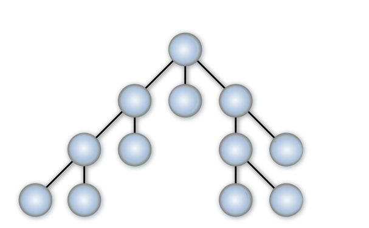

**접기/펼치기**

[figure not shown]

### (4) 휴리스틱 탐색(heuristic search)

- 무정보 탐색(uninformed search)은 사전 정보를 사용하지 않고 일정한 순서대로만 탐색
- 깊이 우선 탐색과 너비 우선 탐색은 무정보 탐색임
- 휴리스틱 탐색은 탐색 과정에서 경험적 지식을 활용
- 휴리스틱 개념은 7.3절의 (3)에서 설명

[figure not shown]

### (5) 최소최대 탐색(minimax search)

- 주로 상대가 있는 2인용 게임에서의 탐색
- 미국 어린이들이 즐기는 틱텍토(Tic-Tac-Toe) 게임
- 가로, 세로, 대각선으로 3개가 연속될 경우 이기는 게임
- 나의 가능성 최대, 상대방의 가능성 최소 전략 탐색
- 탐색이 필요 없는 경로를 잘라내는 작업을 전지 작업(pruning)

[figure not shown]

### 구글에 "틱택토" 검색

- 미니게임이 나와서 바로 게임을 진행할 수 있다.
- 오목과 아주 유사한 형태인 추상전략 게임
- 상, 중, 하 난이도를 조절하여 AI와 플레이 할 수 있다.

[figure not shown]

## 7.3 인공지능과 알고리즘

### (1) 알고리즘(algorithm)이란 무엇인가?

- 인공지능에서 알고리즘이란 용어가 자주 나옴
- 신경망에서의 역전파 알고리즘 등
- 문제 해결을 위한 단계들을 체계적으로 명시한 것
- 문제를 해결하는 방법의 상세한 특징을 기술하는 것
- 표현 방법으로는 순서도, 유사 코드, 언어적 표현 등
- 알고리즘은 단 하나만 있는 것이 아님

[figure not shown]

### (2) 생활 속의 알고리즘

① 기초적인 수학 연산

- 덧셈과 곱셈 방법, 최대공약수를 구하는 방법 등

② 라면 조리법

- 라면을 맛있게 끓이기 위한 조리 방법
- 물의 양, 불의 세기, 끓이는 시간 등이 주요 요소

[figure not shown]

③ 하루의 일정 계획

- 아침에 학교에 가려고 할 때의 일정 계획
- 기상 시간, 식사 시간, 버스나 지하철 이용 등

④ 가전제품의 사용 매뉴얼

- 세탁기나 전자레인지 등의 단계별 사용 설명서

⑤ 지하철 환승 방법

- 어느 지하철역에서의 환승이 효율적인지 판단

⑥ 알파고와 같은 인공지능 방법론

- 바둑이나 게임 등에서 복잡한 것 해결 방법
- 그 외 생활 속의 알고리즘이 매우 많음

### (3) 휴리스틱(heuristic)을 이용한 알고리즘

휴리스틱이란 경험을 통해 얻은 지식이나 직감, 어림짐작을 의미한다.

- 일상생활에서 수많은 일을 겪는데, 이때 문제해결을 위해 정보를 수집하고 판단하는 것은 큰 부담
- 따라서 과거의 경험을 바탕으로 어림직작을 하는 것을 휴리스틱이라 한다
- 휴리스틱은 비슷한 문제에 대한 과거의 경험들을 바탕으로 직관적으로 판단하여 선택하는 의사결정 방식
- 인공지능에서 휴리스틱 알고리즘이 상당히 많이 쓰임
- 논리적이거나 최적의 방법을 보장하는 것은 아님
- 만족할만한 해결책의 비교적 빠른 실용적인 방법
- 현실적으로 만족할 수 있는 답을 찾는 접근법
- 인공지능, 심리학, 경제학 분야에서 많이 사용

### 휴리스틱의 예)

저명한 수학교육자 폴리아의 『How to solve it』에서의 휴리스틱의 예

1. 어떤 문제를 이해하기 어려우면 그림으로 그려보기
2. 해답을 얻었다고 가정하고 반대 방향으로 유도해보기
3. 그 문제가 추상적이면 구체적인 예를 시도해보기

[figure not shown]

### 예시) 주차문제, 학교가는 길 등

- 시행 착오를 거쳐 점점 나아가는 것도 휴리스틱
- 전에 와본 기억을 더듬어 길을 찾는 것 등이 휴리스틱을 이용한 문제 해결

[figure not shown]

- 집에서 학교까지 가는 길은 위의 그림과 같이 하늘색, 보라색, 분홍색 길 세 가지 뿐
- 세 길 모두 오르막이나 내리막 길은 없으며 다른 조건은 비슷하다고 할 때 어떤 길을 선택할 것인가? 또 선택한 이유가 무엇인가?
- 모두 가운데 보라색 길을 골랐을 것이며, 이유는 한 눈에 보기에도 짧은 길이기 때문
- 이처럼 깊은 생각을 하지 않고 순간의 감으로 판단하는 것을 ‘직관적’이라고 하는데, 이렇게 직관적으로 판단하는 것도 사람이 사용하는 휴리스틱이다.

### (4) 인공지능 A* 알고리즘

- A* 알고리즘은 최상우선 탐색 중 가장 잘 알려짐
- 문제 해결에 매우 효과적인 탐색 알고리즘
- 출발점에서 목표지점까지의 최적 경로 탐색의 한 방법
- 가장 비용이 적거나 짧은 경로 찾기
- 평가 함수 f를 사용하여 다음에 이동할 경로를 결정함

[figure not shown]

#### 최단 거리 길찾기 알고리즘

[figure not shown]

### (5) 인공지능 알고리즘의 예: 8-Queens 문제

- 8-Queens 문제는 체스(서양의 장기)에서 유래
- 서로를 공격하지 않는 위치에 8개의 퀸(Q) 배치
- 퀸은 수평, 수직, 대각선 방향으로 몇 칸이든 이동 가능
- 어떤 퀸도 서로 공격 당하지 않는 위치에 놓여야 함

[figure not shown]

### 8-Queens 문제

- 64개의 칸을 가진 8-Queens 문제의 경우의 수?
- 약 44억 가지의 엄청난 경우의 수
- 통상 인공지능 방법으로 프로그램하여 해답을 구함
- 몇 가지의 해답이 나옴

[figure not shown]

### 4-Queens 문제

- 체스 판을 4 x 4로 축소한 소위 4-Queens 문제
- 2가지 경우의 해답을 얻을 수 있음
- 수평, 수직, 대각선 방향으로 점검
- 어떤 퀸도 서로 공격 당하지 않는 위치임을 확인

[figure not shown]

## ※ moral muchine

- moral (도덕) + muchine (기계)
- 자율주행 자동차가 여러 상황에서 누구의 생명을 우선해야 하는지에 대한 사람들의 의견을 수집하는 플랫폼
- 인공 지능이 자율 주행 기술에서 점점 더 중요한 역할을 수행함에 따라 인공 지능이 내려야 하는 결정에 관한 연구에 사용
- Iyad Rahwan과 사회심리학자 Azim Shariff, Jean-François Bonnefon이 자율주행차 윤리에 관한 논문을 발표하기 전에 구상한 아이디어
- MIT Media Lab 연구원이 플랫폼을 구축
- 이른바 ‘트롤리 딜레마’
- 이를 통해 AI의 윤리성, 설계와 규제에 대해 더 깊이 생각하게 될 것
- 누가 죽을 것인지 말 것인지 그리고 편견이 어떻게 발생하는지에 대한 것이 아닌, 누가 더 위험하고 덜 위험한가에 대한 위험 분석으로 옮겨가야 할 것.

주소 : https://www.moralmachine.net/hl/kr

- 13개의 상황 제시, 판단을 통한 자신의 윤리적 판단결과를 볼 수 있음
- 어떤 조건과 측면을 중요시 하는지

### → Trolley dilemma

```python
from IPython.display import YouTubeVideo
YouTubeVideo('yg16u_bzjPE')
# https://youtu.be/yg16u_bzjPE
```

[video not shown]

[figure not shown]

## 7.4 규칙기반 전문가 시스템

### (1) 지식처리 기술과 지식 획득

- 지식처리 기술은 현재 규칙(rule)이나 프레임(frame)에 의한 표현이 실용화
- 규칙(rule)은 “If ooo then xxx”란 형식으로 표현
- 전문가 시스템에서 널리 이용
- 의미 네트워크는 개념 간의 관계를 링크(link)로 연결
- 개와 세퍼드, 개와 진돗개를 링크로 연결
- 의미 네트워크는 지식을 체계화시켜 표현하기에 적합

[figure not shown]

## ※의미네트워크

- 쉽게 말해, 의미네트워크는 지식을 표현하는 그래프 형식의 모델
- 이 모델은 개념들 간의 상호작용을 표현하기 위해 링크로 연결된 노드를 표현하여 다양한 관계를 나타냄
- 지식을 시각화하고 분석하기 쉽게 만들어준다,
- 개념 간의 관계가 시각적으로 표현되기 때문에 복잡한 지식을 쉽게 이해할 수 있다.
- 또한, 의미네트워크는 추론과 결정을 지원하는 인공지능 시스템에서 많이 사용된다.
- 예를 들어, 의료 진단 시스템에서 의미네트워크를 사용하여 환자의 증상과 질병 간의 관계를 모델링하고, 이를 기반으로 진단을 내리는 등의 의사 결정을 지원할 수 있음

[figure not shown]

예시 )

[figure not shown]

### (2) 규칙기반 시스템의 작동 예

- 규칙기반 시스템은 사실(fact)을 나타내는 *지식베이스* 와 If ooo then xxx와 같은 *추론규칙* 으로 이루어짐
- 질의에 대해 지식베이스와 추론규칙을 이용하여 추론한 후 그 결과를 알려줌
  - ‘소크라테스의 죽음’의 간단한 예

[figure not shown]

#### 규칙기반 시스템의 간단한 예 )

[figure not shown]

#### → 규칙기반 시스템의 결과 분석

- ‘Is Socrates die?’란 질의에 대한 답변
- ‘Socrates is a human’이란 지식베이스의 사실과
  - ‘If X is a human, then X dies’란 추론규칙이 결합하여
  - ‘소크라테스는 죽는다’는 답변을 이끌어냄
- 또 ‘Tell me what dies?’에 대해서도
  - ‘Socrates, Daesukim, wurry’가 죽는다는 결론 도출
- 규칙기반 시스템은 Prolog로 편리하게 프로그래밍 가능

### (3) 인간 전문가를 대신하는 전문가 시스템

- 전문가 시스템(Expert System)은 컴퓨터 자문 시스템의 일종
- 특정 분야에서의 인간 전문가의 전문 지식을 활용
- 인공지능의 추론 능력을 이용한 문제 해결 시스템
- 전문가의 지식을 정리하여 지식베이스부터 구축함
- 사용자가 질문하면 추론기구가 지식베이스를 이용하여 추론
- 사용자에게 그 결과를 전해주게 됨

[figure not shown]

#### 전문가 시스템으로 향한 이유

- 규칙기반 인공지능이 전문가 시스템으로 응용
- A* 알고리즘 이후 새로운 알고리즘 발견의 어려움

[figure not shown]

### (4) 전문가 시스템의 적용 분야

- 전문가 시스템은 규칙기반 인공지능 기법 이용
- 전문가의 지식을 손쉽게 이용할 수 있는 장점
- 자동차 전문가 시스템 등 다양한 분야에 적용

[figure not shown]

#### 전문가 시스템의 응용

- 전문가 시스템은 다방면에 걸쳐 응용됨

[figure not shown]

#### 전문가 시스템의 예

- DENDRAL은 스탠퍼드 대학에서 개발한 화학 전문가 시스템
- "Dendritic Algorithm"이라는 용어의 약자
- 분자의 구조를 예측할 수 있도록 개발된 전문가 시스템
- DENDRAL은 휴리스틱을 사용한 후 전문가와 대등한 수준

[figure not shown]

## 7.5 인공지능과 관련된 흥미로운 문제들

### (1) 인공지능 문제 해결을 위한 중요 단계

인공지능과 관련된 문제들은 얼핏 보면 단순하게 보이지만 실제 만만찮은 문제들이 많다.  
주어진 문제를 해결하기 위해서는 여러가지 단계들이 필요하다.  
그 중 가장 중요하다고 생각되는 몇 가지는 다음과 같다.

① 문제를 명확하게 정의  
② 문제에 대한 철저한 분석  
③ 정해진 제약 조건이나 규칙이 있는 경우규칙의 적용에 대한 검증 필요  
④ 최적의 기법 선택  
⑤ 결과가 나오면 과정에 문제점이 없는지 분석, 검토

## (2) 초기의 인공지능 적용 문제 ‘상자 쌓기’

- 일정한 규칙과 목표 상태가 주어진 경우
- 인공지능을 이용하여 적절한 순서를 적용하여 해결하는 방법의 예

[문제 7.1] 상자 쌓기 문제

- 왼쪽에서 상자를 하나씩 옮겨 목표 상태로 만들기
- 작은 번호의 상자가 큰 번호 상자 밑으로 가도록 함
- 상자는 다른 상자 위나 바닥 C에 놓을 수 있음

### 상자의 이동 횟수와 그 방법?

[figure not shown]

### 단 3회의 이동으로 가능

- 먼저 3번 상자를 비어 있는 공간 C에 옮김
- A의 1번 상자 위에 2번, 3번 상자를 차례로 쌓기
- 초기 인공지능이 프로그램을 통해 풀었던 문제

[figure not shown]

### [문제 7.1]의 인공지능적인 풀이

- 규칙기반 시스템의 지식베이스와 추론규칙을 만들어 적용시킬 수 있고, 프로그래밍 언어를 사용하여 해결할 수 있다.

#### 지식베이스

- A 위에는 1,3이 차례로 있다.
- B 위에는 2가 있다.
- C 위에는 아무것도 없다

#### 추론규칙

- 상자를 하나씩 옮겨서 작은 번호의 상자가 밑으로 가도록 한다

#### 목표상태

- A 위에 1,2,3이 차례대로 놓인다.

### 하노이의 탑(Tower of Hanoi)이라는 일종의 퍼즐게임과 비슷.

세 개의 기둥과 이 기둥에 꽂을 수 있는 크기가 다양한 원판들이 있다.  
퍼즐 시작 전, 한 기둥에 원판들이 작은 것이 위에 있도록 순서대로 쌓여 있다.  
한 기둥에 꽂힌 원판들을 그 순서 그대로 다른 기둥으로 옮겨서 다시 쌓는 것.  
하노이의 탑 문제는 재귀 호출을 이용하여 풀 수 있는 가장 유명한 예제 중의 하나이다.  
그렇기 때문에 프로그래밍 수업에서 알고리즘 예제로 많이 사용한다.

[figure not shown]

#### 주소: https://vidkidz.tistory.com/649

- 위에서 설명한 것 처럼 첫번째 기둥에 있는 원판들을 세번째 기등으로 그대로 옮기면 끝나는 퍼즐 게임
- 한번에 하나의 원판만 옮길 수 있다, 큰 원판이 작은 원판 위에 있어서는 안된다

※ 버튼 설명

- disce : 옮길 수 있는 원판숫자
- moves : 내가 옮긴 숫자
- min : 최적해
- reset : 다시하기

[figure not shown]

## (3) 대표적인 인공지능 게임 ‘8-puzzle 게임’

- 인공지능에서 휴리스틱을 사용하는 초기의 예
- 3 × 3 크기의 박스에서 목표 상태로 가는 게임
- 게임 판의 숫자는 빈칸을 향해 상하좌우로 움직임
- 미국 유치원과 초등학생들의 두뇌 향상 게임
- 생각보다 오래 걸리는 경우가 있음

[figure not shown]

[문제 7.2] ‘8-puzzle 게임’의 휴리스틱

- 이 문제를 푸는 휴리스틱은 무엇일까?
- 위치가 맞지 않은 숫자의 개수를 줄여나가는 방향으로 이동 (즉, 위치가 맞는 개수를 늘려나가는 방향)
- 최종적으로 8개의 위치를 모두 일치시키기

[figure not shown]

[문제 7.2] ‘8-puzzle 게임’의 풀이

- 단 3번의 움직임만으로 목표 상태에 도달
- 숫자와 빈 공간인 점(.)의 위치를 맞바꾸면서 진행
- 목표와 일치하는 숫자가 많아지는 방향으로 이동
- 휴리스틱이 잘 적용되지 않는 경우도 가끔 있음
- 이런 점이 휴리스틱의 한계성이기도 함

[figure not shown]

- 이미지로도 많이 사용됨
- 주소: https://murhafsousli.github.io/8puzzle/#/

[figure not shown]

### 8-puzzle 문제를 해결하기 위한 온라인 툴

- 초기 상태를 입력하면, A* 알고리즘 등의 다양한 탐색 알고리즘을 선택하여 문제를 해결하는 과정을 볼 수 있다.
- 주소 : https://deniz.co/8-puzzle-solver/

[figure not shown]

## (4) 인공지능 기법으로 풀어보는 ‘물통 문제’

[문제 7.3] 물통(water jug 또는 물주전자) 문제

- 주어진 사실과 규칙들을 적용하여 문제를 해결
- 4 리터짜리와 3리터짜리 물통이 각각 하나씩 있음
- 물통들에는 용량을 나타내는 어떠한 표시도 없음
- 이러한 눈금이 없는 조건에서 4리터짜리 물통에다 꼭 2리터의 물을 채우는 방법?

※ 사용할 수 있는 몇 가지 규칙이나 동작  
① 물통에 물을 가득 채우기  
② 물통의 물을 전부 다 비우기  
③ 물통에 남은 물을 다른 물통에다 붓기  
④ 물통의 물을 다른 물통이 가득 찰 때까지 붓기

[figure not shown]

### [문제 7.3] 물통 문제의 풀이

①3리터짜리 (물통)에 물을 가득 채우기  
② 그것을 4리터짜리에 모두 붓기  
③ 비어 있는 3리터짜리에다 다시 물을 가득 채우기  
④ 3리터짜리의 물을 4리터짜리가 가득 찰 때까지 붓기  
⑤ 4리터짜리의 물을 모두 비우기  
⑥ 3리터짜리의 물을 4리터짜리에 모두 붓기.

[figure not shown]

물통 문제의 Python 소스 코드 참조 https://cs15.github.io/ai/lab-7/

## (5) 문자 암호 풀이

- 1824년 영국의 유명한 퍼즐왕 헨리 듀드니(Henry Dudeney)가 만들어 발표한 유명한 문자 문제
- 뉴웰(Newell)에 의해 채택된 초기의 인공지능 문제
- 정교한 인공지능 프로그램을 통해 빠르게 해결 수 있음을 보여준 예

[문제 7.4] 각 문자는 0에서 9까지의 각각 다른 숫자 가짐, 각 문자에 해당하는 숫자 구하기

[figure not shown]

### 문자 암호의 풀이

- 같은 영문자는 위치가 달라도 같은 값을 가짐
- 일반적 방법으로는 매우 풀기 어려움
- 가능성 있는 단서들로부터 미지수를 하나씩 풀어나감
- S = 9, E = 5, N = 6, D = 7, M = 1, O = 0, R = 8, Y = 2

[figure not shown]

### 문자 암호의 유사한 문제 풀이

- 인공지능을 이용한 유사한 문제 풀이
- DONALD + GERALD 등

[figure not shown]

## (6) 규칙의 적용을 이용한 문제 해결

[문제 7.5] 늑대, 염소, 양배추 문제

- 사람이 늑대, 염소, 양배추와 함께 강의 오른쪽에 있음
- 사람은 이 중 하나만 선택, 강의 왼쪽/오른쪽으로 이동
- 사람 혼자서 건널 수도 있음
- 늑대와 염소만 남겨 두면 늑대가 염소를 잡아먹음
- 염소와 양배추만 남겨 두면 염소가 양배추를 먹음
- 염소나 양배추가 먹히지 않고 모두 강을 건너는 방법?

[figure not shown]

#### 주소 : https://flasharch.com/archive/play/ba9833bf7c4ae18278346cbc0f194872

[figure not shown]

### 늑대, 염소, 양배추 문제의 풀이 예

① 먼저 양을 태우고 왼쪽으로 이동  
② 양을 내려놓고 오른쪽으로 이동  
③ 늑대를 태우고 왼쪽으로 이동  
④ 늑대를 내려놓고, 양을 태우고 오른쪽으로 이동  
⑤ 양을 내려놓고, 양배추를 태우고 왼쪽으로 이동  
⑥ 양배추를 내려놓고 혼자서 오른쪽으로 이동  
⑦ 양을 태우고 왼쪽으로 이동 완료

[figure not shown]

### [문제 7.6] ‘선교사와 식인종’ 문제

- 3명의 선교사, 3명의 식인종, 배 1척이 왼쪽에 위치
- 목표는 선교사와 식인종 모두 배를 타고 강을 건넘
- 어떤 방법으로 모두 건널 수 있는가?

이동의 제약 조건

- 배에는 최대 2명까지 탈 수 있음
- 선교사와 식인종 누구나 배 조종 가능
- 식인종 수 > 선교사 수, 식인종이 선교사를 해치게 됨

[figure not shown]

주소: https://vidkidz.tistory.com/7850

[문제 7.6] 선교사와 식인종 문제 해결

- 초기 상태와 목표 상태의 명확한 표현이 중요
- 강의 양쪽 둑에 있는 선교사와 식인종의 수?
- 목표 상태로의 이동을 위해 기본 규칙 사용
- 주어진 제약 조건들도 만족시키면서 규칙 사용

선교사 1명과 식인종 1명이 왼쪽에서 오른쪽으로 이동  
선교사 1명이 오른쪽에서 왼쪽으로 이동  
식인종 2명이 왼쪽에서 오른쪽으로 이동  
식인종 1명이 오른쪽에서 왼쪽으로 이동  
선교사 2명이 왼쪽에서 오른쪽으로 이동  
선교사 1명과 식인종 1명이 오른쪽에서 왼쪽으로 이동  
선교사 2명이 왼쪽에서 오른쪽으로 이동  
식인종 1명이 오른쪽에서 왼쪽으로 이동  
식인종 2명이 왼쪽에서 오른쪽으로 이동  
선교사 1명이 오른쪽에서 왼쪽으로 이동  
선교사 1명과 식인종 1명이 왼쪽에서 오른쪽으로 이동  
완료!

[figure not shown]

#### 다이어그램에 의한 문제 풀이

- 다이어그램으로 나타내면 편리함
- 각 상태는 하이픈(-)의 왼쪽과 오른쪽에 나타나 있음
- 화살표는 이동을 나타냄

[figure not shown]

## 규칙기반 인공지능의 문제 해결 요약

- 규칙기반 인공지능 기법을 이용한 주요 문제들
- ‘늑대, 염소, 양배추 문제’ 문제
- ‘선교사와 식인종’ 문제
- 인공지능 언어인 Lisp을 이용하여 편리하게 해결 가능
- 그 외에도 인공지능 규칙을 이용한 문제들이 많음
- 예를 들어 ‘원숭이와 바나나 등이 있음